# Grupo 6

### Alumnos:

### Librerias que vamos a usar

```r
datos <- read.csv('chicos.csv')
library(dplyr)
library(ggplot2)
```

## Funciones auxiliares

```r
MAE <- function(x,y) {
  devolver <- abs(x-y)
  return (round(sum(devolver)/length(x),3))
}

PMAE <- function(x,y) {
  devolver <- abs(x-y)
  return(round(sum(devolver)/sum(x), 3))
}

crossval <- function(datos, modelo, n_obs, fun_error, n_muestras=10) {
  errores <- c()
  for(i in 1:n_muestras){
    azar <- sample(1:nrow(datos), nrow(datos)-n_obs)
    observaciones <- datos[azar,]
    model <- lm(modelo, data = observaciones)
    excluidos <- datos[-azar,]
    prediccion <- as.vector(predict(model, newdata = excluidos))
    errores <- c(errores, fun_error(excluidos$AGE.IN.MONTHS, prediccion))
  }
  devolver <- list('Errores' = errores, 'Promedio errores' = round(mean(errores), 3), 'Varianza errores' = var(errores), 'Formula' = modelo, 'Modelo ajustado' = lm(modelo, data = datos))
  return (devolver)
}

crossval_alt <- function(datos, modelo, n_obs, fun_error, n_muestras=10) {
  errores <- c()
  for(i in 1:n_muestras){
    azar <- sample(1:nrow(datos), nrow(datos)-n_obs)
    observaciones <- datos[azar,]
    model <- lm(modelo, data = observaciones)
    excluidos <- datos[-azar,]
    prediccion <- as.vector(predict(model, newdata = excluidos))
    errores <- c(errores, fun_error(excluidos$STATURE, prediccion))
  }
  devolver <- list('Errores' = errores, 'Promedio errores' = round(mean(errores), 3), 'Varianza errores' = var(errores), 'Formula' = modelo, 'Modelo ajustado' = lm(modelo, data = datos))
  return (devolver)
}
```

#### El PMAE mide el error entre los valores predichos y los reales, en terminos proporcionales.

#### El cross-validation lo que hace es tomar un subconjunto del dataset para armar un modelo lineal y usar ese modelo para predecir los valores del resto del dataset.

## Limpieza del dataset

```r
eliminar_peso <- which(datos$WEIGHT == 0) # Averiguo que filas del dataset tienen peso 0
datos <- datos[setdiff(1:nrow(datos), eliminar_peso),] # Los elimino del dataset
datos$WEIGHT <- datos$WEIGHT/10 # Asi estan en kilogramos
eliminar_altura <- which(datos$STATURE == 0)
datos <- datos[setdiff(1:nrow(datos), eliminar_altura),]
datos$STATURE <- datos$STATURE/10 # Asi estan en centimetros
eliminar_raza <- which(datos$RACE == 0)
datos <- datos[setdiff(1:nrow(datos), eliminar_raza),]
# Eliminar los que tienen  mas de 18?
eliminar_edad <- which(datos$AGE.IN.MONTHS >= 216)
datos <- datos[setdiff(1:nrow(datos), eliminar_edad),]
```

```r
# Con dplyr
datos %>% filter(WEIGHT>0) %>% mutate(WEIGHT = WEIGHT/10) -> datos
datos %>% filter(STATURE > 0) %>% mutate(STATURE = STATURE/10) -> datos
datos %>% filter(RACE > 0) -> datos
datos %>% filter(AGE.IN.MONTHS <216) -> datos
```

```r
par(mfrow=c(3,2))
hist(datos$WEIGHT, breaks = 30, ylab = 'Frecuencia', xlab = '', main = 'Peso en kilogramos')
hist(datos$AGE.IN.MONTHS, breaks = 30, ylab = 'Frecuencia', xlab = '', main = 'Edad en meses')
```

```r
hist(datos$STATURE, breaks = 30, ylab = 'Frecuencia', xlab = '', main = 'Altura en centimetros')
barplot(table(datos$SEX), names.arg = c('Varon', 'Mujer'), main = 'Por sexo')
```

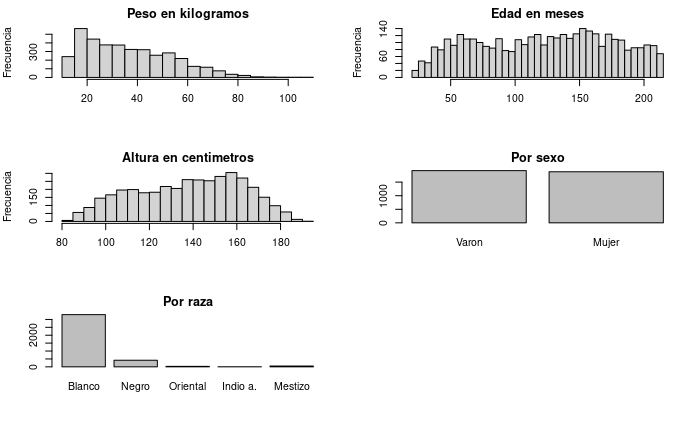

```r
barplot(table(datos$RACE), names.arg = c('Blanco','Negro', 'Oriental', 'Indio a.', 'Mestizo'), main = 'Por raza')
```

#### Estos histogramas nos permiten visualizar como se distribuyen las variables obligatorias. Debido a la enorme cantidad de datos que pertenecen a la raza blanca y los pocos datos pertenecientes a las demas razas, decidimos no tenerlo en cuenta para los modelos.

### Aca vamos a explorar que partes del cuerpo crecen mas rapido y mas lento

#### Pregunta guia: ¿Que partes del cuerpo predicen mejor la edad? ¿Hay alguna diferencia en sexo y raza? ¿Hace alguna diferencia considerar el peso? (Las partes que crecen mas rapido no deberia haber diferencia si el peso no hace diferencia)

### Primero, necesitamos el modelo mas basico, relacionar la edad con la altura, y ese va a ser nuestro parametro para comparar

```r
modelo_basico <- lm(AGE.IN.MONTHS~STATURE, datos)
#
summary(modelo_basico)
```

```
Call:
lm(formula = AGE.IN.MONTHS ~ STATURE, data = datos)

Residuals:
    Min      1Q  Median      3Q     Max
-55.820  -9.421  -0.922   8.120  63.336

Coefficients:
              Estimate Std. Error t value Pr(>|t|)
(Intercept) -1.562e+02  1.389e+00  -112.5   <2e-16 ***
STATURE      2.025e+00  9.922e-03   204.1   <2e-16 ***
---
Signif. codes:  0 ‘***’ 0.001 ‘**’ 0.01 ‘*’ 0.05 ‘.’ 0.1 ‘ ’ 1

Residual standard error: 14.98 on 3804 degrees of freedom
Multiple R-squared:  0.9163,    Adjusted R-squared:  0.9163
F-statistic: 4.164e+04 on 1 and 3804 DF,  p-value: < 2.2e-16
```

```r
# R cuadrado de 0.91
error_basico <- PMAE(datos$AGE.IN.MONTHS, as.vector(predict(modelo_basico)))
#
error_basico
```

```
[1] 0.092
```

```r
# Error con PMAE: 0.09
modelo_basico_S <- lm(AGE.IN.MONTHS~(STATURE+SEX), datos)
summary(modelo_basico_S)
```

```
Call:
lm(formula = AGE.IN.MONTHS ~ (STATURE + SEX), data = datos)

Residuals:
    Min      1Q  Median      3Q     Max
-53.683  -9.561  -0.995   8.078  60.922

Coefficients:
              Estimate Std. Error  t value Pr(>|t|)
(Intercept) -1.638e+02  1.577e+00 -103.869   <2e-16 ***
STATURE      2.029e+00  9.811e-03  206.795   <2e-16 ***
SEX          4.680e+00  4.802e-01    9.746   <2e-16 ***
---
Signif. codes:  0 ‘***’ 0.001 ‘**’ 0.01 ‘*’ 0.05 ‘.’ 0.1 ‘ ’ 1

Residual standard error: 14.8 on 3803 degrees of freedom
Multiple R-squared:  0.9183,    Adjusted R-squared:  0.9183
F-statistic: 2.138e+04 on 2 and 3803 DF,  p-value: < 2.2e-16
```

```r
# El sexo no mejora la prediccion con la edad.
error_basico_S <- PMAE(datos$AGE.IN.MONTHS, as.vector(predict(modelo_basico_S)))
#
error_basico_S
```

```
[1] 0.092
```

```r
# La misma conclusion con PMAE
cant_observaciones <- floor(0.2*nrow(datos))
#
cruzada_basico <- crossval(datos, formula('AGE.IN.MONTHS~STATURE'), cant_observaciones, PMAE)
#
cruzada_basico$`Promedio errores`
```

```
[1] 0.092
```

```r
# La validacion cruzada tambien da 0.09, es muy buena.
```

#### El modelo mas basico que vamos a considerar es relacionar la edad con la altura. El error de ajuste, calculado con PMAE, nos da 0.09. Podemos decir que es un muy buen modelo para predecir la edad en meses de los niños.

### Graficos

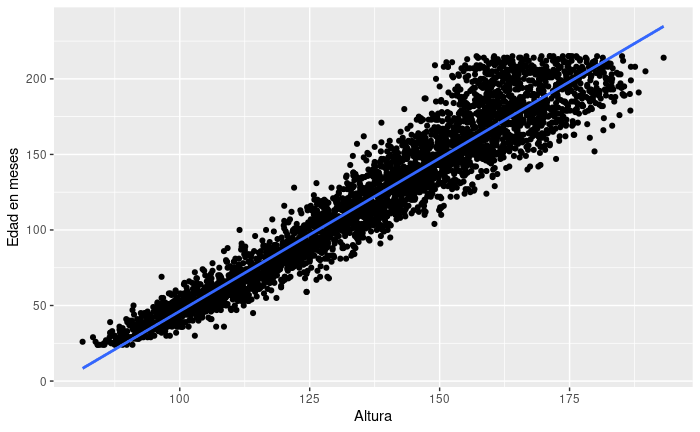

```r
datos_sexo <- as_labeller(c(`1` = 'Varon', `2`= 'Mujer'))
datos_raza <- as_labeller(c(`1`= 'Blanco', `2`= 'Negro', `3`= 'Oriental', `4`= 'Indio americano', `5`= 'Mestizo'))
ggplot(datos, aes(y = AGE.IN.MONTHS, x = STATURE)) + geom_point() + labs(x = 'Altura', y = 'Edad en meses') + geom_smooth(method = 'lm')
```

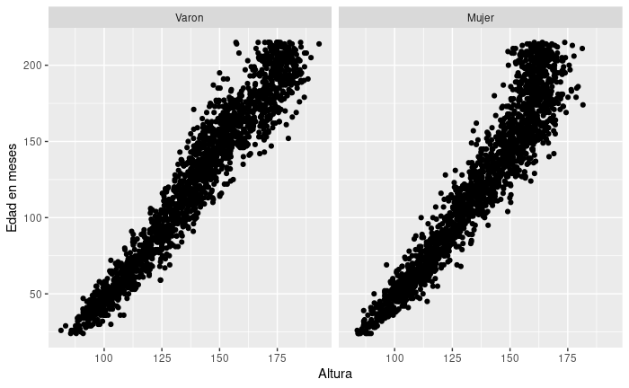

```r
ggplot(datos, aes(y = AGE.IN.MONTHS, x = STATURE)) + geom_point() + facet_grid(col = vars(SEX), labeller = datos_sexo) + labs(x = 'Altura', y = 'Edad en meses')
```

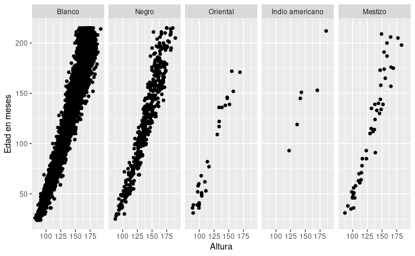

```r
ggplot(datos, aes(y = AGE.IN.MONTHS, x = STATURE)) + geom_point() + facet_grid(col = vars(RACE), labeller = datos_raza) + labs(x = 'Altura', y = 'Edad en meses')
```

```r
# No vamos a ver la variable raza en analisis, porque hay muy pocos datos de otras razas.
```

#### Exploramos en graficos la relacion del modelo mas basico, que relaciona la edad en meses con la altura. Vemos que parece haber una relacion lineal entre ambas variables, aunque a partir del mes 125 aproximadamente los datos empiezan a dispersarse. Tambien vemos la diferencia en cantidad de datos de las distintas razas. Como consideramos que no hay suficientes datos de las otras razas para tener modelos razonables, no la vamos a considerar como variable en nuestros analisis.

### Probamos lo que vimos en los graficos, si hay diferencia en la prediccion de la altura en menores de 125 meses y mayores

```r
datos %>% filter(AGE.IN.MONTHS <= 125) %>% lm(AGE.IN.MONTHS~STATURE,.) -> modelo_basico_1
#
datos %>% filter(AGE.IN.MONTHS <= 125) %>% crossval(formula('AGE.IN.MONTHS~STATURE'), cant_observaciones, PMAE) -> cruzada_basico_1
#
datos %>% filter(AGE.IN.MONTHS > 125) %>% lm(AGE.IN.MONTHS~STATURE,.) -> modelo_basico_2
#
datos %>% filter(AGE.IN.MONTHS > 125) %>% crossval(formula('AGE.IN.MONTHS~STATURE'), cant_observaciones, PMAE) -> cruzada_basico_2
#
datos %>% filter(AGE.IN.MONTHS > 125) %>% lm(AGE.IN.MONTHS~(STATURE+SEX),.) -> modelo_basico_3
#
summary(modelo_basico_1)
```

```
Call:
lm(formula = AGE.IN.MONTHS ~ STATURE, data = .)

Residuals:
    Min      1Q  Median      3Q     Max
-30.994  -5.748  -0.548   5.750  33.407

Coefficients:
              Estimate Std. Error t value Pr(>|t|)
(Intercept) -124.12014    1.62648  -76.31   <2e-16 ***
STATURE        1.72117    0.01373  125.36   <2e-16 ***
---
Signif. codes:  0 ‘***’ 0.001 ‘**’ 0.01 ‘*’ 0.05 ‘.’ 0.1 ‘ ’ 1

Residual standard error: 9.18 on 1887 degrees of freedom
Multiple R-squared:  0.8928,    Adjusted R-squared:  0.8927
F-statistic: 1.572e+04 on 1 and 1887 DF,  p-value: < 2.2e-16
```

```r
# R cuadrado de 0.89
cruzada_basico_1$`Promedio errores`
```

```
[1] 0.091
```

```r
#
summary(modelo_basico_2)
```

```
Call:
lm(formula = AGE.IN.MONTHS ~ STATURE, data = .)

Residuals:
    Min      1Q  Median      3Q     Max
-48.651 -11.887  -1.811   9.725  55.569

Coefficients:
             Estimate Std. Error t value Pr(>|t|)
(Intercept) -75.90544    5.03152  -15.09   <2e-16 ***
STATURE       1.53814    0.03178   48.40   <2e-16 ***
---
Signif. codes:  0 ‘***’ 0.001 ‘**’ 0.01 ‘*’ 0.05 ‘.’ 0.1 ‘ ’ 1

Residual standard error: 16.79 on 1915 degrees of freedom
Multiple R-squared:  0.5502,    Adjusted R-squared:   0.55
F-statistic:  2342 on 1 and 1915 DF,  p-value: < 2.2e-16
```

```r
# R cuadrado de 0.55
cruzada_basico_2$`Promedio errores`
```

```
[1] 0.08
```

```r
# Error PMAE 0.08. Buena capacidad predictiva.
summary(modelo_basico_3)
```

```
Call:
lm(formula = AGE.IN.MONTHS ~ (STATURE + SEX), data = .)

Residuals:
    Min      1Q  Median      3Q     Max
-46.455 -11.833  -1.187  10.632  52.721

Coefficients:
            Estimate Std. Error t value Pr(>|t|)
(Intercept) -91.1368     5.2898 -17.229  < 2e-16 ***
STATURE       1.5761     0.0316  49.880  < 2e-16 ***
SEX           6.2099     0.7628   8.141 6.96e-16 ***
---
Signif. codes:  0 ‘***’ 0.001 ‘**’ 0.01 ‘*’ 0.05 ‘.’ 0.1 ‘ ’ 1

Residual standard error: 16.51 on 1914 degrees of freedom
Multiple R-squared:  0.5653,    Adjusted R-squared:  0.5648
F-statistic:  1244 on 2 and 1914 DF,  p-value: < 2.2e-16
```

```r
# R cuadrado de 0.56
# Hay bastante diferencia entre menores de 125 meses y mayores de 125 meses.
```

#### Para discutir: la diferencia en el error de ajuste y error de validacion para el modelo mas simple en el caso de mayores a 125 meses.

### Vemos la relacion entre la edad y el peso

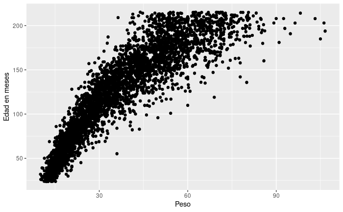

```r
ggplot(datos, aes(x = WEIGHT, y = AGE.IN.MONTHS)) + geom_point() + geom_jitter() + labs(x = 'Peso', y = 'Edad en meses')
```

```r
modelo_peso <- lm(AGE.IN.MONTHS~WEIGHT, datos)
summary(modelo_peso)
```

```
Call:
lm(formula = AGE.IN.MONTHS ~ WEIGHT, data = datos)

Residuals:
    Min      1Q  Median      3Q     Max
-121.52  -15.76   -0.86   16.13   86.51

Coefficients:
            Estimate Std. Error t value Pr(>|t|)
(Intercept) 24.84802    0.87202    28.5   <2e-16 ***
WEIGHT       2.68258    0.02159   124.3   <2e-16 ***
---
Signif. codes:  0 ‘***’ 0.001 ‘**’ 0.01 ‘*’ 0.05 ‘.’ 0.1 ‘ ’ 1

Residual standard error: 23.01 on 3804 degrees of freedom
Multiple R-squared:  0.8024,    Adjusted R-squared:  0.8023
F-statistic: 1.545e+04 on 1 and 3804 DF,  p-value: < 2.2e-16
```

```r
error_peso <- PMAE(datos$AGE.IN.MONTHS, as.vector(predict(modelo_peso)))
error_peso
```

```
[1] 0.149
```

```r
cant_observaciones <- floor(0.2*nrow(datos))
cruzada_peso <- crossval(datos, formula('AGE.IN.MONTHS~WEIGHT'), cant_observaciones, PMAE)
cruzada_peso
```

```
$Errores
 [1] 0.150 0.153 0.149 0.148 0.147 0.154 0.152 0.146 0.148 0.152

$`Promedio errores`
[1] 0.15

$`Varianza errores`
[1] 7.433333e-06

$Formula
AGE.IN.MONTHS ~ WEIGHT

$`Modelo ajustado`

Call:
lm(formula = modelo, data = datos)

Coefficients:
(Intercept)       WEIGHT
     24.848        2.683
```

#### Hay relacion entre el peso y la edad, pero es mas debil que con la altura. El error de ajuste y de prediccion, medido con PMAE, dan muy similar, 0.149.

```r
datos$anio <- trunc(datos$AGE.IN.MONTHS/12)
datos_varon <- datos %>% filter(SEX == 1)
datos_mujer <- datos %>% filter(SEX == 2)

datos_varon %>% group_by(anio) %>% summarise(mean(STATURE)) %>% plot(col = alpha('blue', 1), pch = 19, type = 'b', xlab = 'Año', ylab = 'Altura')
datos_mujer %>% group_by(anio) %>% summarise(mean(STATURE)) %>% points(col = alpha('red', 1), pch = 19, type = 'b')
```

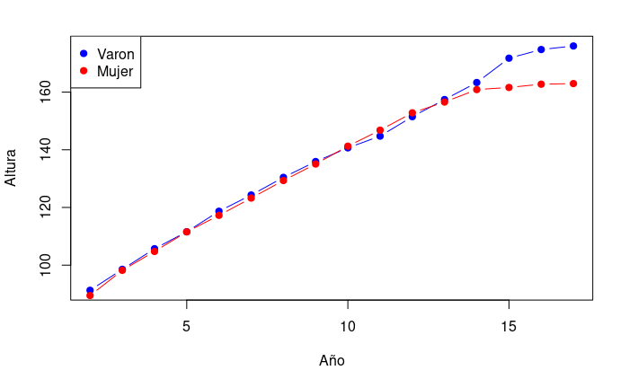

```r
legend('topleft', legend = c('Varon','Mujer'), col = c('blue', 'red'), pch = 19)
```

#### Ahora, como metodo auxiliar, vemos si la edad y altura permiten clasificar bien al sexo del sujeto.

```r
library(caret)
library(class)
train <- datos[,c('STATURE', 'WEIGHT','AGE.IN.MONTHS')]
test <- datos[,c('STATURE', 'WEIGHT', 'AGE.IN.MONTHS')]
labels_train <- datos[,'SEX']
clasif_sexo <- knn(train = train, test = test, cl = labels_train, k = 3)
summary(clasif_sexo)
```

```
   1    2
1987 1819
```

```r
confusionMatrix(clasif_sexo, as.factor(labels_train))
```

```
Confusion Matrix and Statistics

          Reference
Prediction    1    2
         1 1524  463
         2  400 1419

               Accuracy : 0.7733
                 95% CI : (0.7596, 0.7865)
    No Information Rate : 0.5055
    P-Value [Acc > NIR] : < 2e-16

                  Kappa : 0.5463

 Mcnemar's Test P-Value : 0.03481

            Sensitivity : 0.7921
            Specificity : 0.7540
         Pos Pred Value : 0.7670
         Neg Pred Value : 0.7801
             Prevalence : 0.5055
         Detection Rate : 0.4004
   Detection Prevalence : 0.5221
      Balanced Accuracy : 0.7730

       'Positive' Class : 1
```

```r
# Concluimos que usar la altura, el peso y la edad para predecir el sexo es bastante mas debil que usar la altura para predecir la edad. Para nuestros propositos, el sexo no va a ser una variable tan relevante.
```

#### Para nuestros propositos, vemos que la edad, el peso y la altura permiten clasificar a los sujetos de acuerdo a su sexo con una exactitud del 77%. Es decir, tiene un error del 23%. Si comparamos esta clasificacion con el error que habiamos obtenido al relacionar la edad con la altura, podriamos decir que esta clasificacion no es tan buena como nuestro modelo mas simple. Predecimos que el sexo no va a ser una variable relevante para nuestros propositos, aunque lo vamos a poner a prueba.

### Empezamos con distintos modelos y variables:

### Largo pie (86)

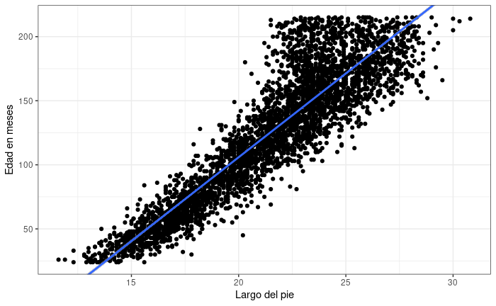

```r
datos %>% filter(FOOT.LENGTH > 0) %>% mutate(FOOT.LENGTH = FOOT.LENGTH/10) -> datos_pie
ggplot(datos_pie, aes(x = FOOT.LENGTH, y = AGE.IN.MONTHS)) + geom_point() + labs(x = 'Largo del pie', y = 'Edad en meses') + theme_bw() + geom_smooth(method = lm)+ coord_cartesian(y = c(24,215))
```

```r
# Del grafico vemos que en edades iniales la edad y la longitud del pie estan muy relacionados, pero en edades mas grandes se dispersa. Suponemos que sera una buena variable predictora solo en edades iniciales. Punto de corte = 125 meses

modelo_pie <- lm(AGE.IN.MONTHS~FOOT.LENGTH, datos_pie)
#
summary(modelo_pie)
```

```
Call:
lm(formula = AGE.IN.MONTHS ~ FOOT.LENGTH, data = datos_pie)

Residuals:
    Min      1Q  Median      3Q     Max
-68.971 -13.590  -2.218  10.864  87.480

Coefficients:
              Estimate Std. Error t value Pr(>|t|)
(Intercept) -155.60554    2.15079  -72.35   <2e-16 ***
FOOT.LENGTH   13.07559    0.09938  131.56   <2e-16 ***
---
Signif. codes:  0 ‘***’ 0.001 ‘**’ 0.01 ‘*’ 0.05 ‘.’ 0.1 ‘ ’ 1

Residual standard error: 21.86 on 3744 degrees of freedom
Multiple R-squared:  0.8222,    Adjusted R-squared:  0.8221
F-statistic: 1.731e+04 on 1 and 3744 DF,  p-value: < 2.2e-16
```

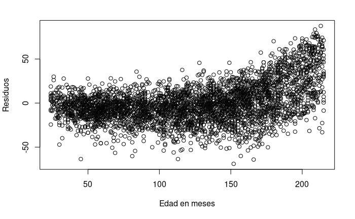

```r
# R cuadrado de 0.82, es una buena relacion
plot(residuals(modelo_pie)~datos_pie$AGE.IN.MONTHS, xlab = 'Edad en meses', ylab = 'Residuos')
```

```r
# Este grafico va a ir una sola vez para ver el ruido
cant_observaciones <- floor(0.2*nrow(datos_pie))
cruzada_pie <- crossval(datos_pie, formula('AGE.IN.MONTHS~FOOT.LENGTH'), cant_observaciones, PMAE)
#
cruzada_pie$`Promedio errores`
```

```
[1] 0.132
```

```r
# El error de prediccion es de 0.13, que esta bastante bien
PMAE(datos_pie$AGE.IN.MONTHS, as.vector(predict(modelo_pie)))
```

```
[1] 0.133
```

```r
# El error de ajuste con PMAE es igual al de prediccion
modelo_pie_altura <- lm(AGE.IN.MONTHS~(FOOT.LENGTH+STATURE), datos_pie)
summary(modelo_pie_altura)
```

```
Call:
lm(formula = AGE.IN.MONTHS ~ (FOOT.LENGTH + STATURE), data = datos_pie)

Residuals:
    Min      1Q  Median      3Q     Max
-49.805  -9.427  -0.810   7.963  63.431

Coefficients:
              Estimate Std. Error t value Pr(>|t|)
(Intercept) -149.23665    1.43867 -103.73   <2e-16 ***
FOOT.LENGTH   -3.91645    0.25760  -15.20   <2e-16 ***
STATURE        2.57973    0.03779   68.27   <2e-16 ***
---
Signif. codes:  0 ‘***’ 0.001 ‘**’ 0.01 ‘*’ 0.05 ‘.’ 0.1 ‘ ’ 1

Residual standard error: 14.59 on 3743 degrees of freedom
Multiple R-squared:  0.9208,    Adjusted R-squared:  0.9207
F-statistic: 2.175e+04 on 2 and 3743 DF,  p-value: < 2.2e-16
```

```r
#Mejora la relacion a 0.92
modelo_pie_ES <- lm(STATURE~FOOT.LENGTH, datos_pie)
summary(modelo_pie_ES)
```

```
Call:
lm(formula = STATURE ~ FOOT.LENGTH, data = datos_pie)

Residuals:
    Min      1Q  Median      3Q     Max
-23.398  -4.111  -0.501   3.593  26.230

Coefficients:
            Estimate Std. Error t value Pr(>|t|)
(Intercept) -2.46882    0.62087  -3.976 7.13e-05 ***
FOOT.LENGTH  6.58676    0.02869 229.587  < 2e-16 ***
---
Signif. codes:  0 ‘***’ 0.001 ‘**’ 0.01 ‘*’ 0.05 ‘.’ 0.1 ‘ ’ 1

Residual standard error: 6.31 on 3744 degrees of freedom
Multiple R-squared:  0.9337,    Adjusted R-squared:  0.9337
F-statistic: 5.271e+04 on 1 and 3744 DF,  p-value: < 2.2e-16
```

```r
# Pensamos que el modelo es tan bueno porque el pie esta muy relacionado con la altura. R cuadrado = 0.93
```

#### Esta es una buena variable que se explica principalmente por su relacion con la altura.